# ML7 (vragen Rein)

Wytze Vlietstra

1/9/2018

# Introductie

Naar aanleiding van de email van Rein op 08-01-2017 heb ik de volgende vragen beantwoord:

- Wat is de verdeling tussen kankers en ziekten binnen de positieve en de negatieve set?
- Hoe vaak komen specifieke kankers/ziekten binnen de positieve/negatieve set voor, en correleren die getallen?
- Wat is het verschil in classificatie performance tussen de ziekten en de kankers?
- Wat is de onderlinge verdeling in ICD categorieen van de ziekten tussen de positieve en de negatieve set?

# Experimenten

```r
# Geef aan of de ziekten kankers zijn of niet
repoDB = read.csv("~/pRojects/Tareq/ML5/RepoDB.csv", stringsAsFactors = F)
cancers = read.csv2("~/pRojects/Tareq/ML6/Neoplastic process.csv", stringsAsFactors = F, header = F)

repoDB$type = ifelse(repoDB$ind_name %in% cancers$V1, "Cancer", "Disease")
```

## Verdelingen en correlaties

In totaal zijn er 511 unieke kankers, en 1375 unieke ziekten in de data.

Als we kijken naar de approved drugs, dan zien we dat die als volgt onderverdeeld zijn.

### Positieve cases

```r
print(as.data.frame(table(repoDB$type[repoDB$status == "Approved"])))
```

```
##      Var1 Freq
## 1  Cancer  458
## 2 Disease 6219
```

### Negatieve cases

```r
print(as.data.frame(table(repoDB$type[repoDB$status == "Terminated"])))
```

```
##      Var1 Freq
## 1  Cancer 1925
## 2 Disease  829
```

## Correlaties

Hieronder staat de verdeling van de ziekten verdeeld over de twee klassen, en de correlatie ertussen. Ik bereken de correlaties alleen op basis van de ziekten die zowel in de positieve als de negatieve set voorkomen.

### Correlaties ziekten

```r
# Hoe vaak komt het per individuele ziekte voor dat ze accepted of terminated zijn?
# Diseases
pos_diseases = as.data.frame(table(repoDB$ind_name[repoDB$status == "Approved" & repoDB$type == "Disease"]))
neg_diseases = as.data.frame(table(repoDB$ind_name[repoDB$status == "Terminated" & repoDB$type == "Disease"]))

disease_freq = merge(pos_diseases, neg_diseases, by = "Var1")
print(cor(disease_freq$Freq.x, disease_freq$Freq.y, method = "spearman"))
```

```
## [1] 0.2564863
```

Als je alle ziekten meeneemt, dus ook degene die alleen in de positieve cases of negatieve cases voorkomen, heb je 1375 ziekten. Als je alleen de ziekten meeneemt die in zowel de positieve klasse als de negatieve klasse voorkomen, heb je 112 ziekten.

Correlatie tussen de frequenties van de ziekten tussen de positieve en de negatieve cases lijkt dus laag te zijn.

### Correlaties kankers

Ik voer dezelfde analyse uit voor de kankers

```r
pos_cancers = as.data.frame(table(repoDB$ind_name[repoDB$status == "Approved" & repoDB$type == "Cancer"]))
neg_cancers = as.data.frame(table(repoDB$ind_name[repoDB$status == "Terminated" & repoDB$type == "Cancer"]))
cancer_freq = merge(pos_cancers, neg_cancers, by = "Var1")

print(cor(cancer_freq$Freq.x, cancer_freq$Freq.y, method = "spearman"))
```

```
## [1] 0.2702636
```

Als je alle kankers meeneemt, dus ook degene die alleen in de positieve cases of negatieve cases voorkomen, heb je 511 kankers Als je alleen de kankers meeneemt die in zowel de positieve klasse als de negatieve klasse voorkomen, heb je 35 kankers.

Ook hier is de correlatie laag.

### Classificeren op basis van ICD codes

```r
require(RMySQL)
require(yaml)
config = yaml.load_file("~/pRojects/Tareq/ML7/config.yml")

db = dbConnect(MySQL(), user= config$Mi_bios1$user, password= config$Mi_bios1$pass,
               dbname = config$Mi_bios1$db, host= config$Mi_bios1$host)

crossmap_query = paste('SELECT CUI, CODE FROM MRCONSO WHERE CUI IN ("', paste(repoDB$ind_id, collapse = '", "'), '") AND SAB = "ICD10"', sep = "")
mapping_file = dbGetQuery(db, crossmap_query)

out = dbDisconnect(db)

mapping_file$class = substr(mapping_file$CODE, 1,1)

repoDB = merge(repoDB, mapping_file[,c("CUI", "class")], by.x = "ind_id", by.y = "CUI", all.x = T)
```

Bij het mappen van de CUI’s naar de ICD codes lijkt er iets fout te gaan. Ongeveer de helft van de CUI’s gaan verloren omdat ze geen ICD code lijken te hebben. Waar we beginnen met 10809, eindigen we met 5653.

Als we deze categorieen plotten voor de positieve en de negatieve cases, dan zien we de volgende verdelingen:

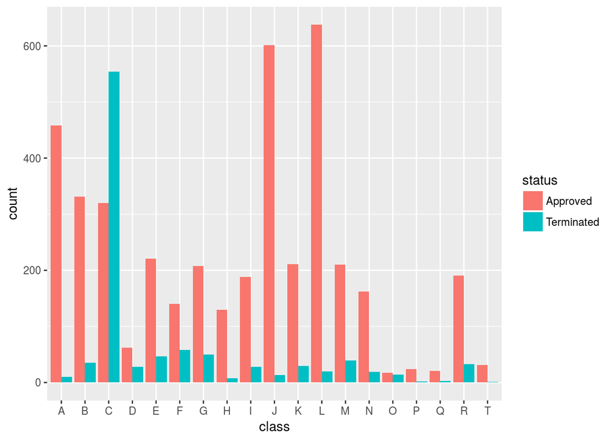

```r
require(ggplot2)

ggplot(data = repoDB[repoDB$status %in% c("Approved", "Terminated") & !is.na(repoDB$class), ]) +
geom_histogram(aes(x = class, fill = status), stat = "count", position = "dodge")
```

Dit kan ook nog uniek per ziekte in de negatieve/postieve cases.

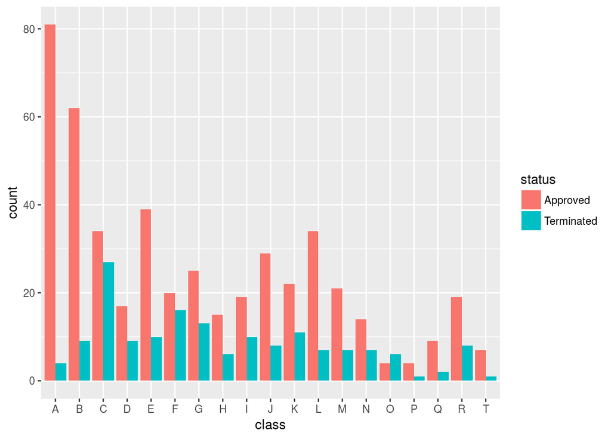

```r
repo2 = repoDB[repoDB$status %in% c("Approved", "Terminated") & !is.na(repoDB$class), ]
repo2 = repo2[!duplicated(repo2[,c("status", "ind_id")]),]

ggplot(data = repo2) +
geom_histogram(aes(x = class, fill = status), stat = "count", position = "dodge")
```

Het lijkt me duidelijk uit deze twee figuren dat de positieve en negatieve cases totaal niet parallel lopen.

## Verschil in classificatie tussen diseases en kankers

Eerst classificeer ik de combinaties, waarna ik apart de performance uit voor de kankers en de ziekten uitreken, inclusief precision, recall, en F1.

```r
require(caret)
require(randomForest)
require(doMC)
require(plyr)
require(pROC)
registerDoMC(cores = 22)

# Columns which should not be used for classification
exclusion_columns = c("Drug", "Disease", "Drugbank.ID", "Disease.ID", "drug_ids", "disease_ids", "goldstandard")

# Create the positive set
count_pos = read.csv("~/pRojects/Tareq/Datasets 2/count_pos.csv", stringsAsFactors = F)
diversity_pos = read.csv("~/pRojects/Tareq/Datasets 2/diversity_pos.csv", stringsAsFactors = F)
pos = merge(count_pos, diversity_pos, by = intersect(colnames(count_pos), colnames(diversity_pos)))
pos$goldstandard = "VALID"

# Create the negative set
count_neg = read.csv("~/pRojects/Tareq/Datasets 2/count_neg.csv", stringsAsFactors = F)
diversity_neg = read.csv("~/pRojects/Tareq/Datasets 2/diversity_neg.csv", stringsAsFactors = F)
neg = merge(count_neg, diversity_neg, by = intersect(colnames(count_neg), colnames(diversity_neg)))
neg$goldstandard = "INVALID"

all = rbind.fill(pos, neg)
all[is.na(all)] = 0

pos[is.na(pos)] = 0
neg[is.na(neg)] = 0

# Some columns are empty, meaning their sum is 0. Others are not relevant as features. These are also removed
all$direct = as.logical(all$direct)
goldstandard = factor(all$goldstandard, levels = c("VALID", "INVALID"))

feature_set = all[,-which(colnames(all) %in% exclusion_columns)]

model =  train(x = feature_set, y = goldstandard, method = "rf",
              trControl=trainControl(method="cv", number = 10, classProbs = TRUE,
              savePredictions = TRUE, summaryFunction = twoClassSummary),
              prox=TRUE, allowParallel=TRUE, metric = "ROC")
```

```r
# Print the performance metrics
kable(model$results[model$results$mtry == model$bestTune$mtry, c("ROC", "Sens", "Spec")], row.names = F)
```

| ROC | Sens | Spec |
| --- | --- | --- |
| 0.9540767 | 0.9460759 | 0.804275 |

```r
# Separate the cancers and the diseases, and examine their performance separately
all$class = ifelse(all$Disease %in% cancers$V1, "Cancer", "Disease")
all$names = make.names(rownames(all))

predictions = model$pred[model$pred$mtry == model$bestTune$mtry,]
predictions = predictions[order(predictions$rowIndex), ]
predictions$class = all$class
```

### Performance metrics voor de kankers

De performance metrics voor de kankers worden hieronder getoond. Er wordt een AUC gehaald van 0.929 .

In de kruistabel zijn verticaal de predicties, en horizontaal de referentie.

```r
confmat = confusionMatrix(predictions$pred[predictions$class == "Cancer"], predictions$obs[predictions$class == "Cancer"])

kable(confmat$table)
```

|  | VALID | INVALID |
| --- | --- | --- |
| VALID | 290 | 346 |
| INVALID | 43 | 1596 |

```r
print(confmat$byClass)
```

```
##          Sensitivity          Specificity       Pos Pred Value
##            0.8708709            0.8218332            0.4559748
##       Neg Pred Value            Precision               Recall
##            0.9737645            0.4559748            0.8708709
##                   F1           Prevalence       Detection Rate
##            0.5985552            0.1463736            0.1274725
## Detection Prevalence    Balanced Accuracy
##            0.2795604            0.8463520
```

### Performance metrics for the diseases

De performance metrics voor de ziekten worden hieronder getoond.  
Er wordt een AUC gehaald van 0.94 .

In de kruistabel zijn verticaal de predicties, en horizontaal de referentie.

```r
confmat = confusionMatrix(predictions$pred[predictions$class == "Disease"], predictions$obs[predictions$class == "Disease"])

kable(confmat$table)
```

|  | VALID | INVALID |
| --- | --- | --- |
| VALID | 5061 | 184 |
| INVALID | 262 | 582 |

```r
print(confmat$byClass)
```

```
##          Sensitivity          Specificity       Pos Pred Value
##            0.9507796            0.7597911            0.9649190
##       Neg Pred Value            Precision               Recall
##            0.6895735            0.9649190            0.9507796
##                   F1           Prevalence       Detection Rate
##            0.9577971            0.8741994            0.8311710
## Detection Prevalence    Balanced Accuracy
##            0.8613894            0.8552854
```

Let op: in de getallen hierboven kunnen kleine verschillen zitten met de eerdere getallen, aangezien de eerste analyses uitgevoerd werden op de originele repoDB, terwijl de machine learning experimenten uitgevoerd worden op de features. Bij het creeeren van de features was geen perfecte recall, dus de getallen zullen iets lager zijn.

# SessionInfo